# Data Overview Report

Aitor Vázquez Veloso

2024-09-22

## Data Overview

This report provides an overview of the dataset.

### Column: IFN_TREE_ID

Type: character

Number of missing values: 0

[output not shown]

[output cut: 144 more lines]

### Column: INVENTORY_ID

Type: character

Number of missing values: 0

```
##
##    IFN2    IFN3    IFN4
##  853287 1398537 1121874
```

### Column: province

Type: integer

Number of missing values: 0

```
##    Min. 1st Qu.  Median    Mean 3rd Qu.    Max.
##    1.00   15.00   25.00   24.91   36.00   50.00
```

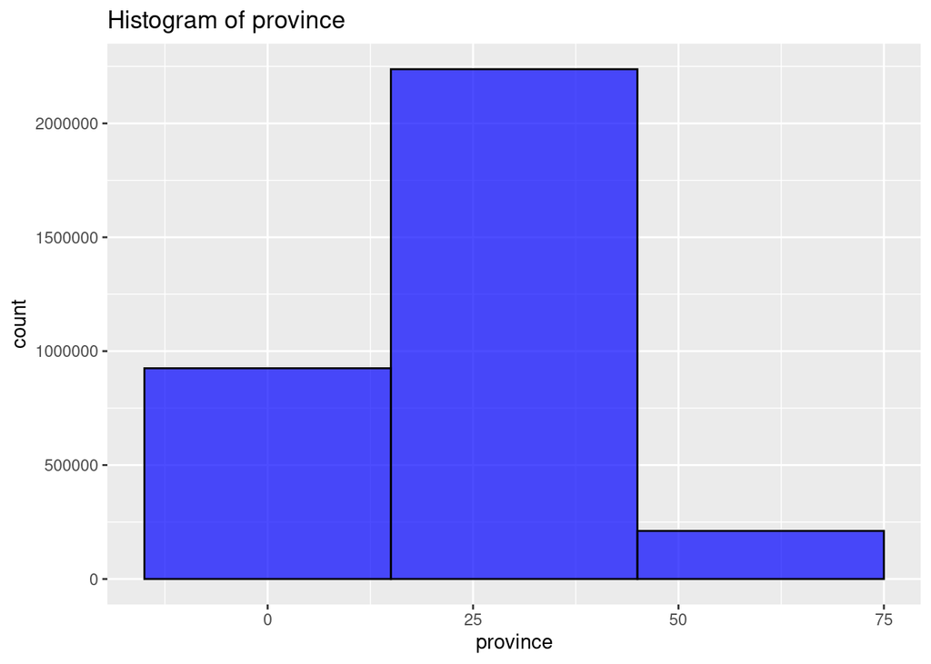

### Column: n_plot

Type: integer

Number of missing values: 0

```
##    Min. 1st Qu.  Median    Mean 3rd Qu.    Max.
##       1     506    1052    1245    1796    6095
```

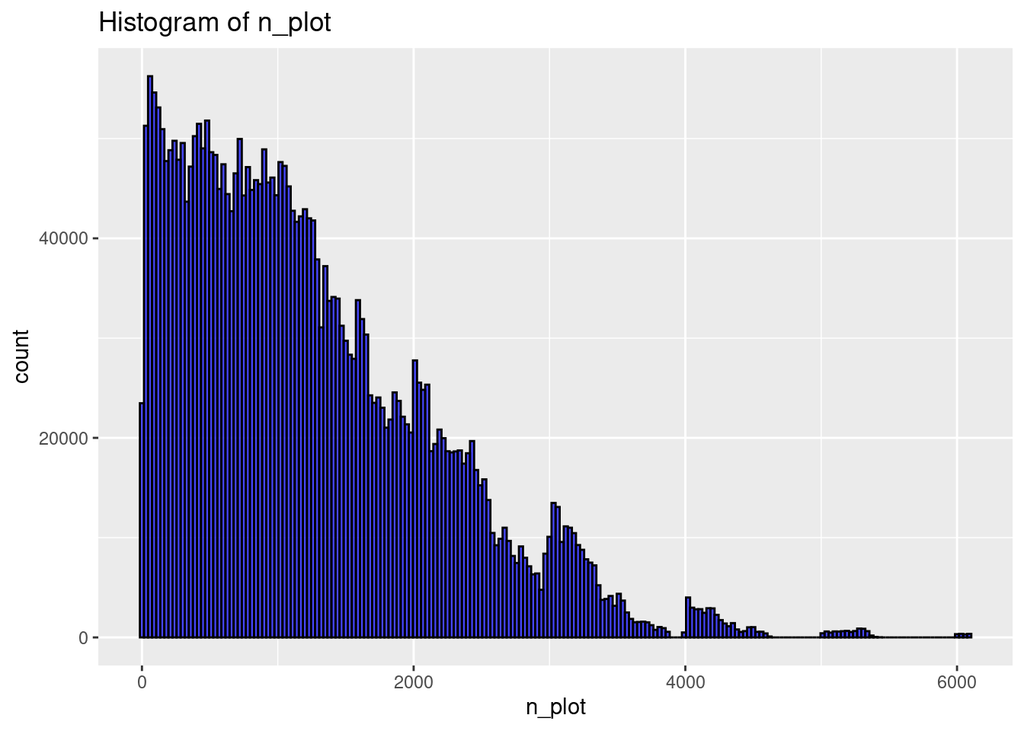

### Column: class

Type: character

Number of missing values: 853287

```
##
##       1       2       3       4       A       N       R
##    4979    2321     316      75 2203515  300246    8959
```

### Column: subclass

Type: character

Number of missing values: 853287

```
##
##       1      1R       2      2C      2E      2R       3      3C      3E       4      4C       5      6C       N       R
## 1818690     373    1975    6948    5431     255     292   82846   56791  213143   18623     161   14637  298420    1826
```

### Column: n_tree

Type: integer

Number of missing values: 0

```
##    Min. 1st Qu.  Median    Mean 3rd Qu.    Max.
##    0.00    5.00   12.00   15.09   22.00 2525.00
```

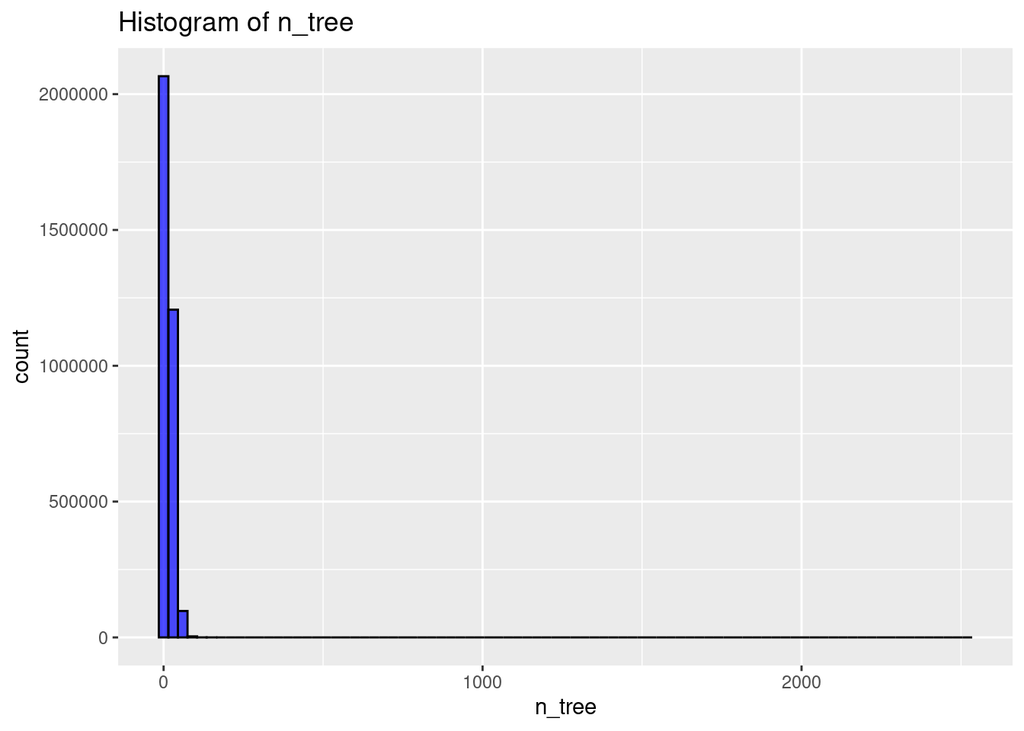

### Column: PLOT_ID

Type: character

Number of missing values: 0

[output not shown]

[output cut: 110 more lines]

### Column: PLOT_ID_short

Type: character

Number of missing values: 0

[output not shown]

[output cut: 54 more lines]

### Column: IFN_PLOT_ID

Type: character

Number of missing values: 0

[output not shown]

[output cut: 110 more lines]

### Column: TREE_ID

Type: character

Number of missing values: 0

[output not shown]

[output cut: 144 more lines]

### Column: species

Type: integer

Number of missing values: 193301

```
##    Min. 1st Qu.  Median    Mean 3rd Qu.    Max.    NA's
##    1.00   24.00   26.00   48.96   45.00  957.00  193301
```

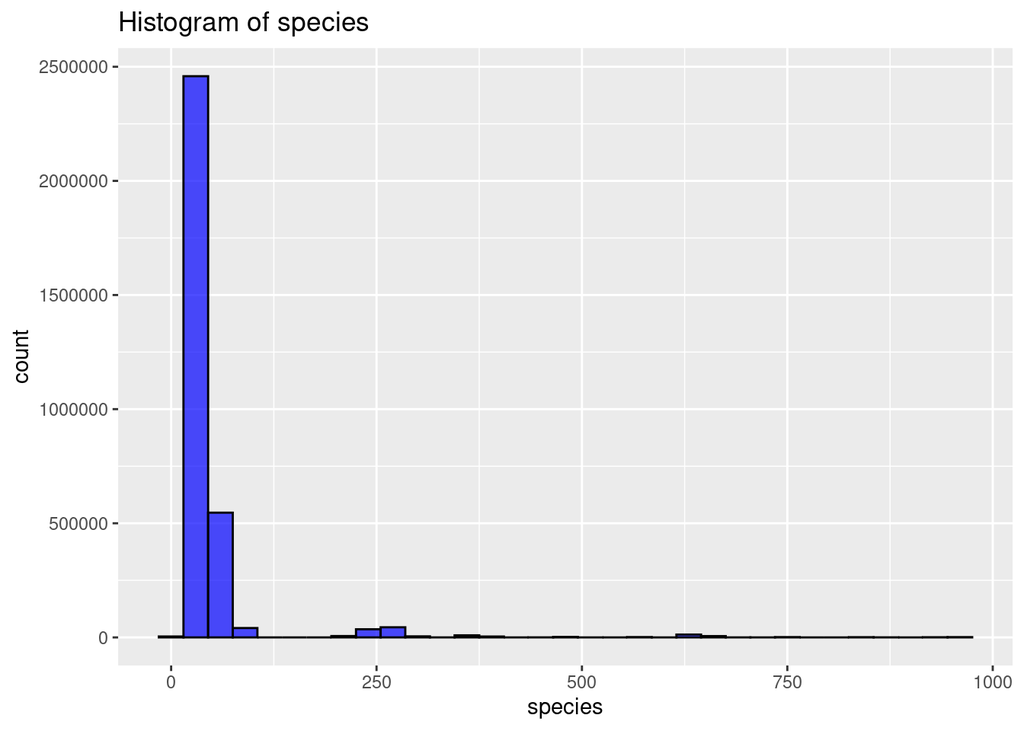

### Column: dbh_1

Type: integer

Number of missing values: 120730

```
##    Min. 1st Qu.  Median    Mean 3rd Qu.    Max.    NA's
##     0.0   147.0   223.0   247.7   308.0  3071.0  120730
```

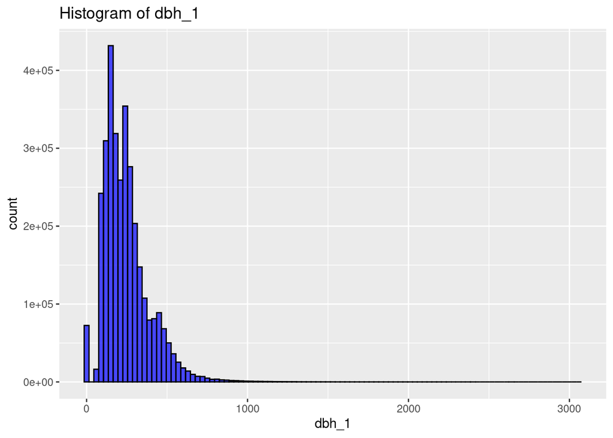

### Column: dbh_2

Type: integer

Number of missing values: 120730

```
##    Min. 1st Qu.  Median    Mean 3rd Qu.    Max.    NA's
##     0.0   146.0   223.0   247.4   308.0  3071.0  120730
```

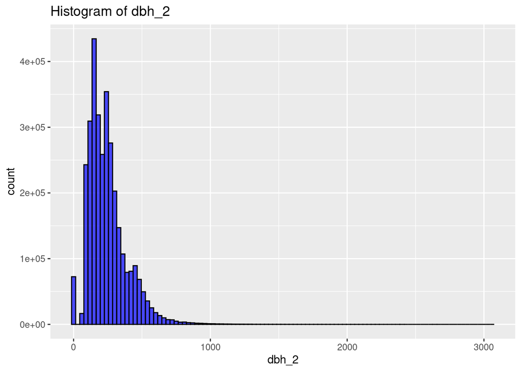

### Column: h

Type: double

Number of missing values: 142709

```
##    Min. 1st Qu.  Median    Mean 3rd Qu.    Max.    NA's
##    0.00    7.50   11.00   11.92   15.30   80.00  142709
```

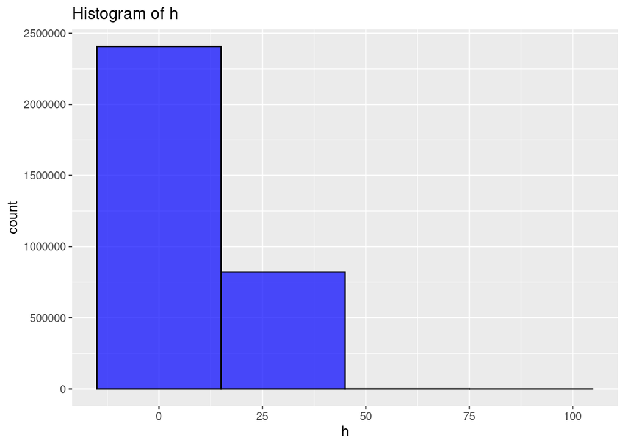

### Column: distance

Type: double

Number of missing values: 175934

```
##    Min. 1st Qu.  Median    Mean 3rd Qu.    Max.    NA's
##    0.00    4.80    8.10    8.66   11.50   92.00  175934
```

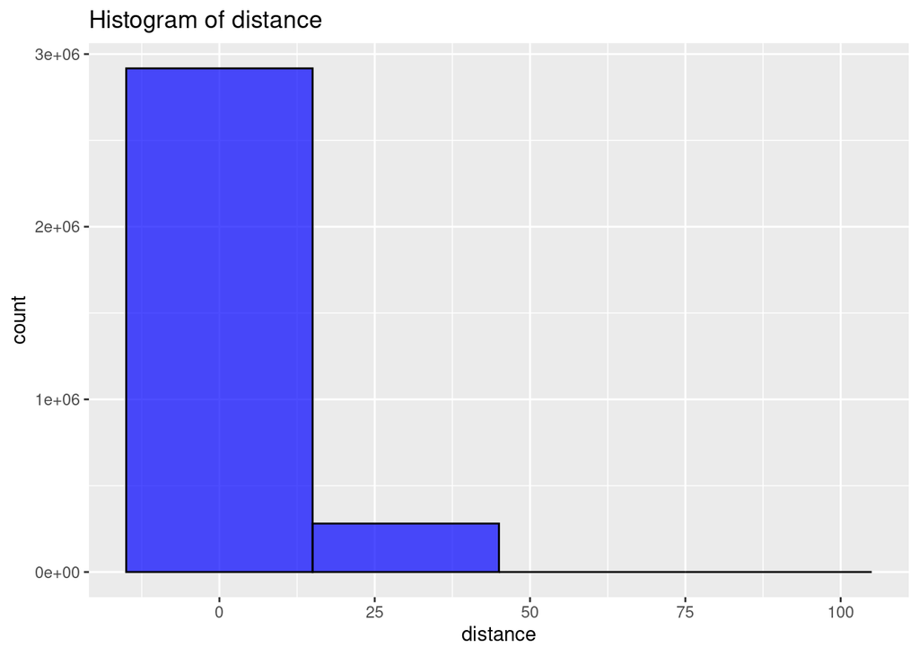

### Column: bearing

Type: double

Number of missing values: 120728

```
##    Min. 1st Qu.  Median    Mean 3rd Qu.    Max.    NA's
##     0.0    94.0   195.0   194.4   295.0  2260.0  120728
```

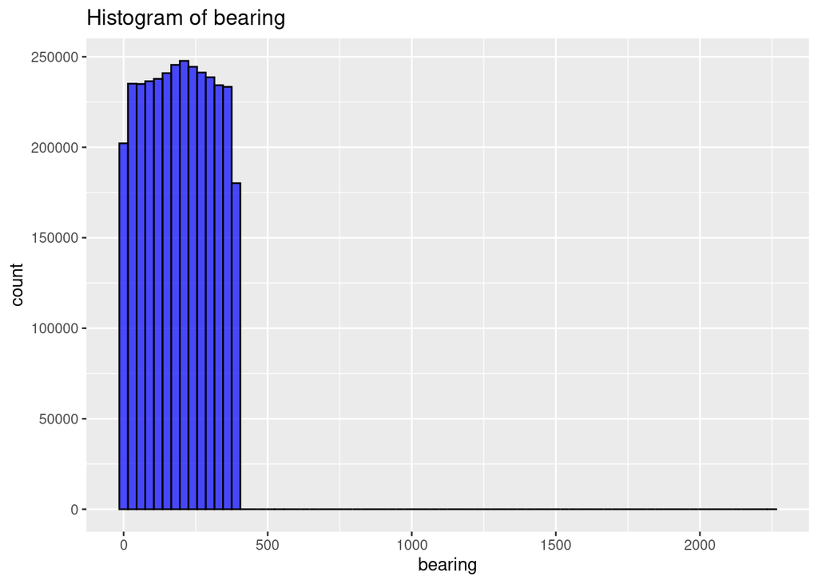

### Column: quality

Type: integer

Number of missing values: 195806

```
##    Min. 1st Qu.  Median    Mean 3rd Qu.    Max.    NA's
##    1.00    2.00    2.00    2.42    3.00   33.00  195806
```

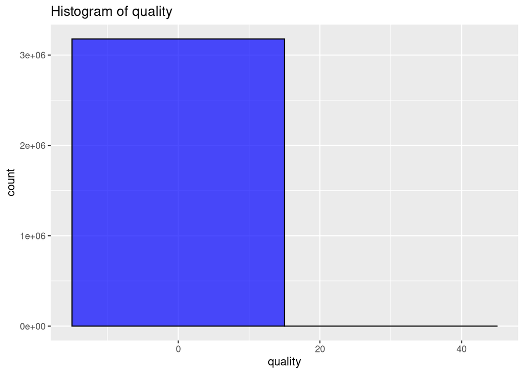

### Column: shape

Type: integer

Number of missing values: 239673

```
##    Min. 1st Qu.  Median    Mean 3rd Qu.    Max.    NA's
##    1.00    2.00    2.00    2.73    3.00    6.00  239673
```

[figure not shown]

### Column: special_param

Type: double

Number of missing values: 2703525

```
##    Min. 1st Qu.  Median    Mean 3rd Qu.    Max.    NA's
##     0.0    41.0    49.0   604.2   226.0  4930.0 2703525
```

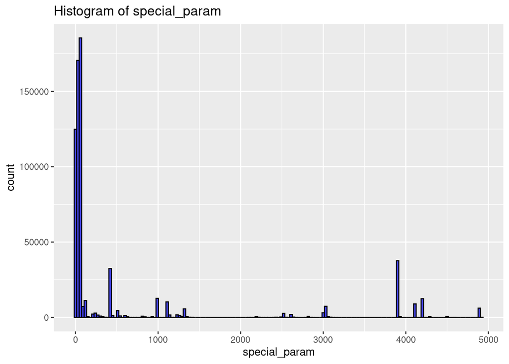

### Column: dbh

Type: double

Number of missing values: 120730

```
##    Min. 1st Qu.  Median    Mean 3rd Qu.    Max.    NA's
##    0.00   14.65   22.50   24.76   30.80  307.10  120730
```

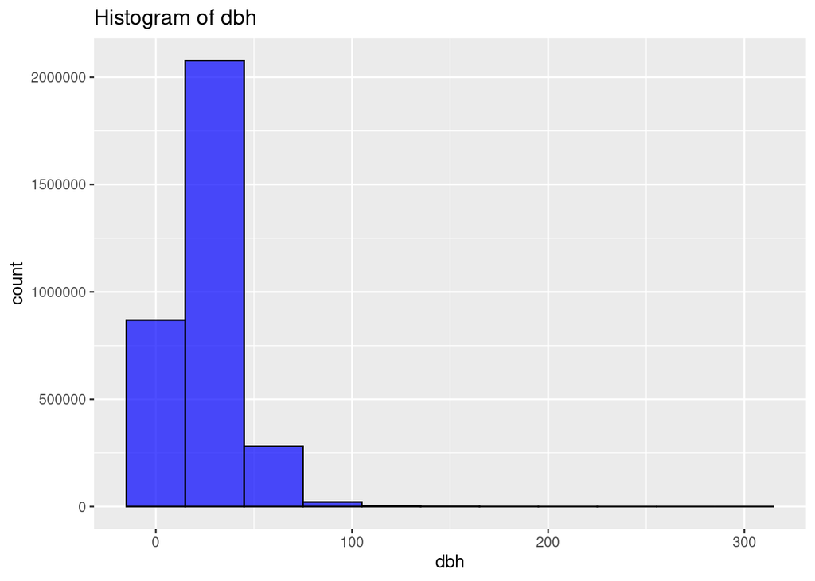

### Column: expan

Type: double

Number of missing values: 120730

```
##    Min. 1st Qu.  Median    Mean 3rd Qu.    Max.    NA's
##    0.00   14.15   14.15   32.01   31.83  127.32  120730
```

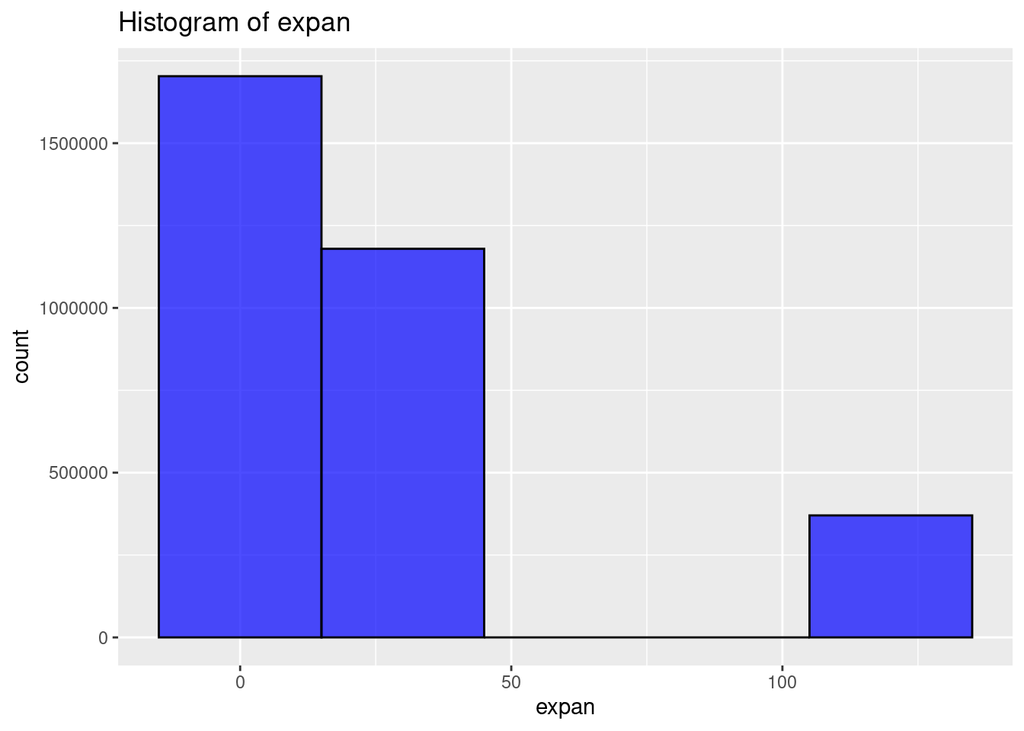

### Column: circumference

Type: double

Number of missing values: 120730

```
##    Min. 1st Qu.  Median    Mean 3rd Qu.    Max.    NA's
##    0.00   46.02   70.69   77.78   96.76  964.78  120730
```

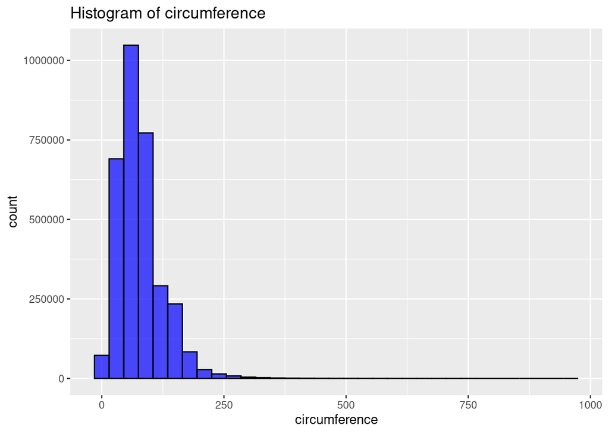

### Column: g

Type: double

Number of missing values: 120730

```
##    Min. 1st Qu.  Median    Mean 3rd Qu.    Max.    NA's
##     0.0   168.6   397.6   645.7   745.1 74071.2  120730
```

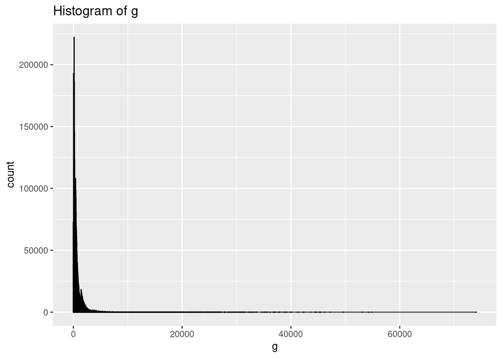

### Column: g_ha

Type: double

Number of missing values: 120730

```
##    Min. 1st Qu.  Median    Mean 3rd Qu.    Max.    NA's
##    0.00    0.62    0.81    0.89    1.07   37.72  120730
```

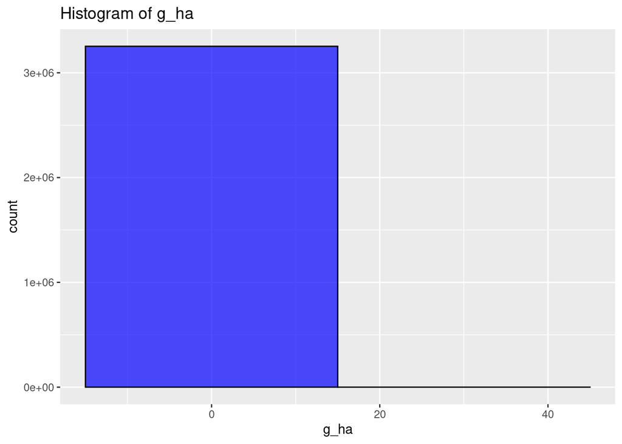

### Column: slenderness

Type: double

Number of missing values: 215218

```
##    Min. 1st Qu.  Median    Mean 3rd Qu.    Max.    NA's
##    0.00   37.91   49.71     Inf   64.69     Inf  215218
```

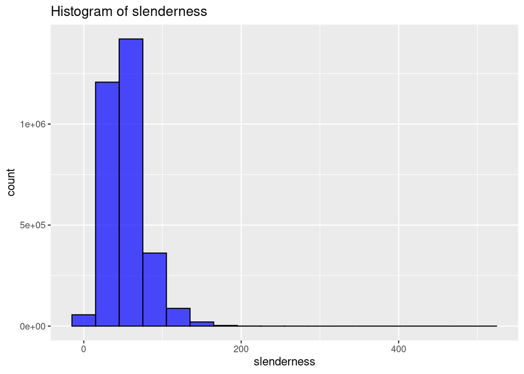

### Column: dead

Type: double

Number of missing values: 195806

```
##    Min. 1st Qu.  Median    Mean 3rd Qu.    Max.    NA's
##    0.00    0.00    0.00    0.02    0.00    1.00  195806
```

[figure not shown]

### Column: x_rel

Type: double

Number of missing values: 175941

```
##    Min. 1st Qu.  Median    Mean 3rd Qu.    Max.    NA's
##    0.00    4.79    8.10    8.64   11.50   92.00  175941
```

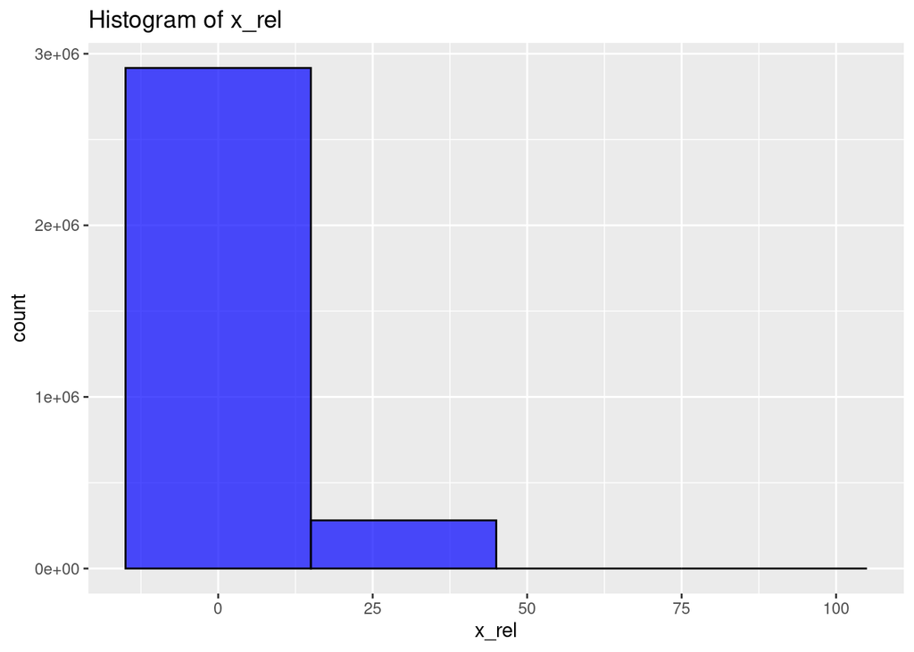

### Column: y_rel

Type: double

Number of missing values: 175941

```
##    Min. 1st Qu.  Median    Mean 3rd Qu.    Max.    NA's
##    0.00    0.14    0.32    0.42    0.61    3.58  175941
```

[figure not shown]

### Column: x_utm

Type: double

Number of missing values: 244229

```
##    Min. 1st Qu.  Median    Mean 3rd Qu.    Max.    NA's
##   32005  386005  504013  495094  594891  776485  244229
```

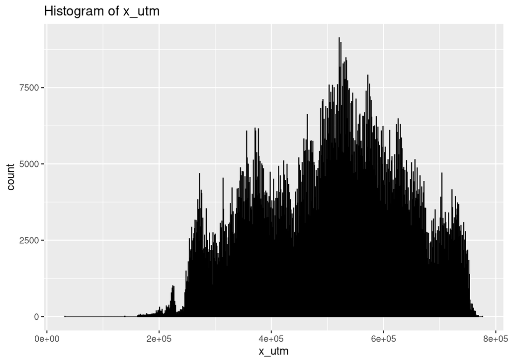

### Column: y_utm

Type: double

Number of missing values: 232219

```
##    Min. 1st Qu.  Median    Mean 3rd Qu.    Max.    NA's
## 2365000 4472791 4656000 4550687 4736000 4848001  232219
```

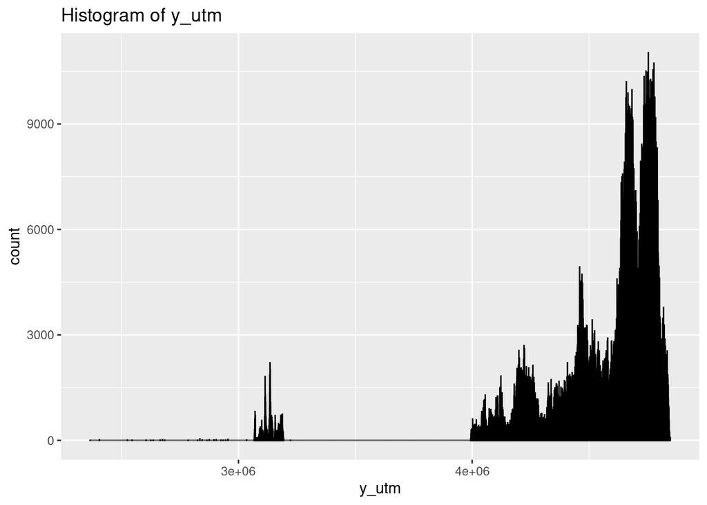

### Column: longitude

Type: double

Number of missing values: 245435

```
##    Min. 1st Qu.  Median    Mean 3rd Qu.    Max.    NA's
##  -18.14   -5.66   -2.92   -3.39   -0.94    4.30  245435
```

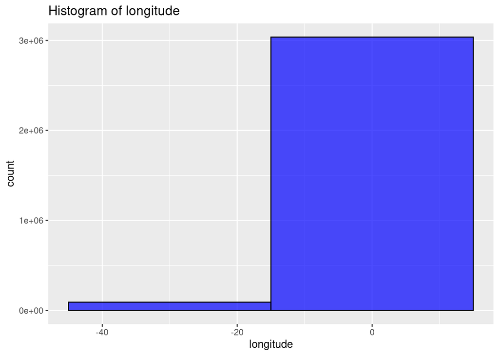

### Column: latitude

Type: double

Number of missing values: 245435

```
##    Min. 1st Qu.  Median    Mean 3rd Qu.    Max.    NA's
##   27.69   40.40   42.06   41.15   42.77   43.78  245435
```

[figure not shown]